# Spyros’ Demo for Dell Interview

## Case 1: some quick filtering

Print a few rows to see if the data was imported correctly

```
  X  Company   Product           TypeName     Inches  ScreenResolution                     Cpu                          Ram    Memory                Gpu                            OpSys        Weight    Price_euros
---  --------  ----------------  ----------  -------  -----------------------------------  ---------------------------  -----  --------------------  -----------------------------  -----------  -------  ------------
  1  Apple     MacBook Pro       Ultrabook      13.3  IPS Panel Retina Display 2560x1600   Intel Core i5 2.3GHz         8GB    128GB SSD             Intel Iris Plus Graphics 640   macOS        1.37kg        1339.69
  2  Apple     Macbook Air       Ultrabook      13.3  1440x900                             Intel Core i5 1.8GHz         8GB    128GB Flash Storage   Intel HD Graphics 6000         macOS        1.34kg         898.94
  3  HP        250 G6            Notebook       15.6  Full HD 1920x1080                    Intel Core i5 7200U 2.5GHz   8GB    256GB SSD             Intel HD Graphics 620          No OS        1.86kg         575.00
  4  Apple     MacBook Pro       Ultrabook      15.4  IPS Panel Retina Display 2880x1800   Intel Core i7 2.7GHz         16GB   512GB SSD             AMD Radeon Pro 455             macOS        1.83kg        2537.45
  5  Apple     MacBook Pro       Ultrabook      13.3  IPS Panel Retina Display 2560x1600   Intel Core i5 3.1GHz         8GB    256GB SSD             Intel Iris Plus Graphics 650   macOS        1.37kg        1803.60
  6  Acer      Aspire 3          Notebook       15.6  1366x768                             AMD A9-Series 9420 3GHz      4GB    500GB HDD             AMD Radeon R5                  Windows 10   2.1kg          400.00
  7  Apple     MacBook Pro       Ultrabook      15.4  IPS Panel Retina Display 2880x1800   Intel Core i7 2.2GHz         16GB   256GB Flash Storage   Intel Iris Pro Graphics        Mac OS X     2.04kg        2139.97
  8  Apple     Macbook Air       Ultrabook      13.3  1440x900                             Intel Core i5 1.8GHz         8GB    256GB Flash Storage   Intel HD Graphics 6000         macOS        1.34kg        1158.70
  9  Asus      ZenBook UX430UN   Ultrabook      14.0  Full HD 1920x1080                    Intel Core i7 8550U 1.8GHz   16GB   512GB SSD             Nvidia GeForce MX150           Windows 10   1.3kg         1495.00
 10  Acer      Swift 3           Ultrabook      14.0  IPS Panel Full HD 1920x1080          Intel Core i5 8250U 1.6GHz   8GB    256GB SSD             Intel UHD Graphics 620         Windows 10   1.6kg          770.00
```

I want to see laptops that fulfill all of the requirements below:

1. at least 16GB of RAM
2. have SSD
3. Lighter than 2kg
4. under 1350 Euros:

```
Company   Product         Ram    Memory                 Weight    Price_euros
--------  --------------  -----  ---------------------  -------  ------------
HP        Probook 430     16GB   512GB SSD              1.49kg           1197
Asus      VivoBook S15    16GB   256GB SSD +  1TB HDD   1.5kg            1262
Dell      Inspiron 5379   16GB   512GB SSD              1.62kg           1279
```

## Case 2: A simple grouping by marketing channel

This is what the raw data looks like:

```r
leadsDf1 = read.csv('olist_marketing_qualified_leads_dataset.csv')
kable(head(leadsDf1,10), format = 'simple')
```

```
mql_id                             first_contact_date   landing_page_id                    origin
---------------------------------  -------------------  ---------------------------------  ---------------
dac32acd4db4c29c230538b72f8dd87d   2018-02-01           88740e65d5d6b056e0cda098e1ea6313   social
8c18d1de7f67e60dbd64e3c07d7e9d5d   2017-10-20           007f9098284a86ee80ddeb25d53e0af8   paid_search
b4bc852d233dfefc5131f593b538befa   2018-03-22           a7982125ff7aa3b2054c6e44f9d28522   organic_search
6be030b81c75970747525b843c1ef4f8   2018-01-22           d45d558f0daeecf3cccdffe3c59684aa   email
5420aad7fec3549a85876ba1c529bd84   2018-02-21           b48ec5f3b04e9068441002a19df93c6c   organic_search
28bdfd5f057764b54c38770f95c69f2f   2018-01-14           22c29808c4f815213303f8933030604c   organic_search
126a0d10becbaafcb2e72ce6848cf32c   2018-05-15           6a110e795dd487f1cf8d7583671987af   email
f76136f54d14a3345951f25b7932366b   2018-05-24           d51b0d02f063ba1d053db6d97226eec3   email
2f838cade4a6012a6cb1016d1d8d95ed   2017-11-10           aeac92c0f5ae22a04ed3b746cce3a1b6   organic_search
7281942387a1a0c3f72a50a8b0bb0920   2017-12-25           88740e65d5d6b056e0cda098e1ea6313   social
```

```r
leadsCountByOrigin = leadsDf1 %>%
  group_by(origin) %>%
  count()
```

Now, the number of leads by itself do not tell us much, unless we have a cost estimate for each of these marketing channels. Let’s assume some spending for each

```r
leadsCountByOrigin2 = leadsCountByOrigin %>%
  mutate(total_cost = runif(1, 9999, 49999),
         leads_per_thousand_dollars = n*1000 / total_cost) %>%
  filter(origin != '')
kable(leadsCountByOrigin2, format = 'simple')
```

```
origin                  n   total_cost   leads_per_thousand_dollars
------------------  -----  -----------  ---------------------------
direct_traffic        499     36160.64                    13.799536
display               118     17285.08                     6.826696
email                 493     26970.96                    18.278918
organic_search       2296     19832.70                   115.768379
other                 150     35804.91                     4.189369
other_publicities      65     45072.59                     1.442118
paid_search          1586     34759.39                    45.627956
referral              284     15016.72                    18.912255
social               1350     14968.73                    90.188037
unknown              1099     11858.30                    92.677667
```

## Case 3: Who should we target? Who is more likely to spend more?

This is what the raw data looks like:

```r
retailMarketingDf1 = read.csv('retailMarketingDI.csv')
kable(head(retailMarketingDf1,10), format = 'simple')
```

```
Age      Gender   OwnHome   Married   Location    Salary   Children  History    Catalogs   AmountSpent
-------  -------  --------  --------  ---------  -------  ---------  --------  ---------  ------------
Old      Female   Own       Single    Far          47500          0  High              6           755
Middle   Male     Rent      Single    Close        63600          0  High              6          1318
Young    Female   Rent      Single    Close        13500          0  Low              18           296
Middle   Male     Own       Married   Close        85600          1  High             18          2436
Middle   Female   Own       Single    Close        68400          0  High             12          1304
Young    Male     Own       Married   Close        30400          0  Low               6           495
Middle   Female   Rent      Single    Close        48100          0  Medium           12           782
Middle   Male     Own       Single    Close        68400          0  High             18          1155
Middle   Female   Own       Married   Close        51900          3  Low               6           158
Old      Male     Own       Married   Far          80700          0  NA               18          3034
```

Let’s convert categorical data into numeric, so we can include them when checking correlations

```r
retailMarketingLevels = retailMarketingDf1 %>%
  mutate(
    Age = case_when(
      tolower(Age)=='young'~ 1,
      tolower(Age)=='middle'~ 2,
      tolower(Age)=='old'~ 3
      ),
    Gender = case_when(
      tolower(Gender) == 'male' ~ 0,
      tolower(Gender) == 'female' ~ 1
    ),
    OwnHome = case_when(
      tolower(OwnHome) == 'rent' ~ 0,
      tolower(OwnHome) == 'own' ~ 1
    ),
      Married = case_when(
      tolower(Married) == 'married' ~ 1,
      TRUE ~ 0
    ),
        Location = case_when(
      tolower(Location) == 'close' ~ 0,
      tolower(Location) == 'far' ~ 1
    ),
        History = case_when(
      tolower(History) == 'low' ~ 1,
      tolower(History) == 'medium' ~ 2,
      tolower(History) == 'high' ~ 3
    )
  )
```

Now that we prepared the data, let’s create a correlation plot:

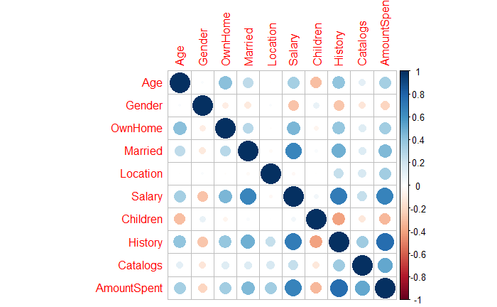

```r
myCorrelations = cor(retailMarketingLevels, use="complete.obs")
corrplot::corrplot(myCorrelations)
```

We are trying to predict who is more likely to spend more:

The strongest positive correlation (predictor for spending more) are the size of Salary and the History with the company. Some negative corrlatation can be found with the number of children: people with more children tend to spend less. Women tend to spend a little less than men on our products, but the correlation is not very strong so we should not take that for granted, more of a possibility to re-test in the future with more data. Married people also seem to spend more than single.

So, our target would be: Higher income married couples. We should make sure to engage our existing customers (have history with us) as they tend to spend more on average than new customers.